# My Circuit Library

## Two Qubit Gates

### Controlled rotation around the Y axis

First, let's apply the Y gate to various θ angles (0°, 45°, 90°, 135°, 180°, 225°, and 315°). Interestingly, the resultant φ angles are 90°, 180°, 180°, 180°, 180°, 0°, and 0°, respectively. It seems that except for an initial angle of 0, the φ angle is 180° if the resultant vector ends up in the rear half of the sphere and 0° if the resultant vector ends up in the front half of the sphere.

```python
display_single_qubit(lambda qc: (qc.y(0)), 0, 0, suppress_initial=True)
```

$$ \text{Circuit = } \begin{bmatrix} 0 & -i \\ i & 0 \\ \end{bmatrix} $$

$$ \text{Final statevector for θ = 180.0°, φ = 90.0°, |a|² = 0.0, |b|² = 1.0 = } \begin{bmatrix} 0 & i \\ \end{bmatrix} $$

$$ \text{Circuit = } \begin{bmatrix} 0 & -i \\ i & 0 \\ \end{bmatrix} $$

$$ \text{Final statevector for θ = 135.0°, φ = 180.0°, |a|² = 0.146, |b|² = 0.854 = } \begin{bmatrix} -0.38268i & 0.92388i \\ \end{bmatrix} $$

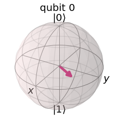

```python
display_single_qubit(lambda qc: (qc.y(0)), pi / 4, 0, suppress_initial=True)
```

$$ \text{Circuit = } \begin{bmatrix} 0 & -i \\ i & 0 \\ \end{bmatrix} $$

$$ \text{Final statevector for θ = 90.0°, φ = 180.0°, |a|² = 0.5, |b|² = 0.5 = } \begin{bmatrix} -\tfrac{1}{\sqrt{2}}i & \tfrac{1}{\sqrt{2}}i \\ \end{bmatrix} $$

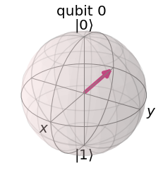

```python
display_single_qubit(lambda qc: (qc.y(0)), pi / 2, 0, suppress_initial=True)
```

$$ \text{Circuit = } \begin{bmatrix} 0 & -i \\ i & 0 \\ \end{bmatrix} $$

$$ \text{Final statevector for θ = 45.0°, φ = 180.0°, |a|² = 0.854, |b|² = 0.146 = } \begin{bmatrix} -0.92388i & 0.38268i \\ \end{bmatrix} $$

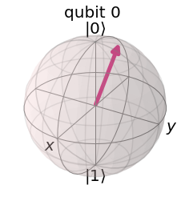

```python
display_single_qubit(lambda qc: (qc.y(0)), 3 * pi / 4, 0, suppress_initial=True)
```

```python
display_single_qubit(lambda qc: (qc.y(0)), pi, 0, suppress_initial=True)
```

$$ \text{Circuit = } \begin{bmatrix} 0 & -i \\ i & 0 \\ \end{bmatrix} $$

$$ \text{Final statevector for θ = 0.0°, φ = 180.0°, |a|² = 1.0, |b|² = 0.0 = } \begin{bmatrix} -i & 0 \\ \end{bmatrix} $$

$$ \text{Circuit = } \begin{bmatrix} 0 & -i \\ i & 0 \\ \end{bmatrix} $$

$$ \text{Final statevector for θ = 45.0°, φ = 0.0°, |a|² = 0.854, |b|² = 0.146 = } \begin{bmatrix} -0.92388i & -0.38268i \\ \end{bmatrix} $$

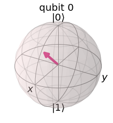

```python
display_single_qubit(lambda qc: (qc.y(0)), 5 * pi /4, 0, suppress_initial=True)
```

$$ \text{Circuit = } \begin{bmatrix} 0 & -i \\ i & 0 \\ \end{bmatrix} $$

$$ \text{Final statevector for θ = 135.0°, φ = 0.0°, |a|² = 0.146, |b|² = 0.854 = } \begin{bmatrix} -0.38268i & -0.92388i \\ \end{bmatrix} $$

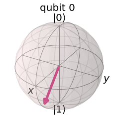

```python
display_single_qubit(lambda qc: (qc.y(0)), 7 * pi /4, 0, suppress_initial=True)
```

An arbitrary controlled rotation around the Y axis can be built from more basic gates. Both control and target bits start in the entangled state.

$$ \text{Circuit = } \begin{bmatrix} 1 & 0 & 0 & 0 \\ 0 & 0 & 0 & -1 \\ 0 & 0 & 1 & 0 \\ 0 & 1 & 0 & 0 \\ \end{bmatrix} $$

$$ \text{Statevector = } \begin{bmatrix} \tfrac{1}{2} & -\tfrac{1}{2} & \tfrac{1}{2} & \tfrac{1}{2} \\ \end{bmatrix} $$

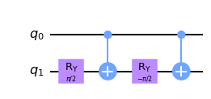

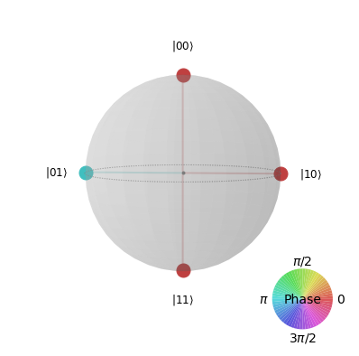

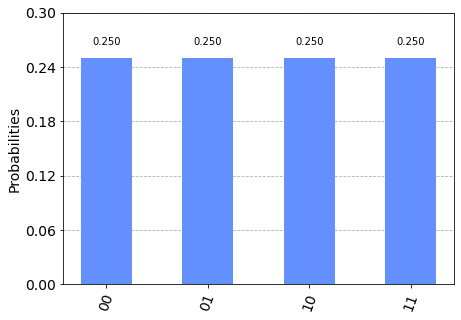

```python
theta = pi
c = 0  # control qubit
t = 1  # target qubit
display_two_qubits(lambda qc: (qc.h(0), qc.h(1)),
                   lambda qc: (qc.ry(theta/2,t), qc.cx(c,t), qc.ry(-theta/2,t),
                               qc.cx(c,t)))
```

If the control qubit is in the state |0>, the Y axis rotations are reversed, and nothing happens. This corresponds to the resultant states |00> and |10>. If, on the other hand, the control bit is in the state |1>, a flip around the Y axis occurs. As can be seen in the statevector, state |01> is offset from |11> by 180°. This makes sense from the previous single Y gate results, since the Y gate applied to an entangled state (θ = 90°, φ = 0°) results in the final state of θ = 90°, φ = 180°.

$$ \text{Circuit = } \begin{bmatrix} \tfrac{1}{\sqrt{2}} & \tfrac{1}{\sqrt{2}} \\ \tfrac{1}{2}(1 + i) & \tfrac{1}{2}(-1 - i) \\ \end{bmatrix} $$

$$ \text{Initial statevector for θ = 0.0°, φ = 0.0°, |a|² = 1.0, |b|² = 0.0 = } \begin{bmatrix} 1 & 0 \\ \end{bmatrix} $$

$$ \text{Final statevector for θ = 90.0°, φ = 45.0°, |a|² = 0.5, |b|² = 0.5 = } \begin{bmatrix} \tfrac{1}{\sqrt{2}} & \tfrac{1}{2}(1 + i) \\ \end{bmatrix} $$

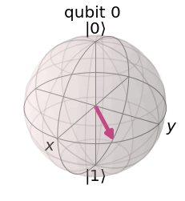

```python
display_single_qubit(lambda qc: (qc.h(0), qc.t(0)), 0, 0)
```

## Quantum Teleportation

Alice starts by generating a random quantum state. Alice and Bob also share an entangled state.

Start with the necessary imports and define several methods.

```python
# Do the necessary imports
import numpy as np
from qiskit import QuantumCircuit, QuantumRegister, ClassicalRegister
from qiskit import IBMQ, Aer, transpile, assemble
from qiskit.visualization import plot_histogram, plot_bloch_multivector, array_to_latex
from qiskit.extensions import Initialize
from qiskit_textbook.tools import random_state

def create_bell_pair(qc, a, b):
    """Creates a bell pair in qc using qubits a & b"""
    qc.h(a) # Put qubit a into state |+>
    qc.cx(a,b) # CNOT with a as control and b as target

def alice_gates(qc, psi, a):
    qc.cx(psi, a)
    qc.h(psi)

def measure_and_send(qc, a, b):
    """Measures qubits a & b and 'sends' the results to Bob"""
    qc.barrier()
    qc.measure(a,0)
    qc.measure(b,1)

# This function takes a QuantumCircuit (qc), integer (qubit)
# and ClassicalRegisters (crz & crx) to decide which gates to apply
def bob_gates(qc, qubit, crz, crx):
    # Here we use c_if to control our gates with a classical
    # bit instead of a qubit
    qc.x(qubit).c_if(crx, 1) # Apply gates if the registers
    qc.z(qubit).c_if(crz, 1) # are in the state '1'
```

### Demonstration using simulated statevector

First, use the simulated statevector to show that the exact quantum state can be determined by Bob. A random quantum state is generated each time, so Bob should see the exact same state upon reconstruction.

$$ |\psi\rangle = \begin{bmatrix} 0.30907 - 0.90662i & 0.26359 - 0.11415i \\ \end{bmatrix} $$

```
Figure(288x288)
Figure(935.31x325.08)
Figure(864x288)
```

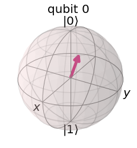

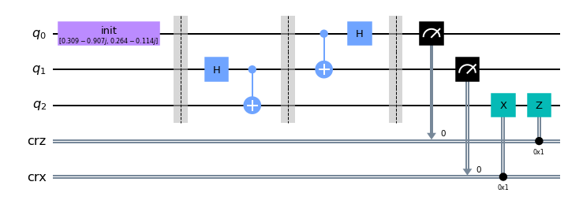

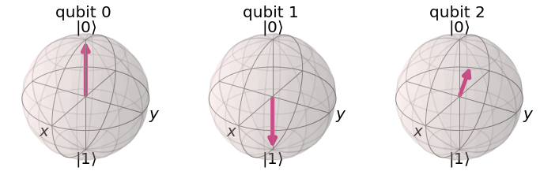

```python
# Let's create our initialization instruction to create |ψ⟩ from the state |0⟩

# Create random 1-qubit state
psi = random_state(1)

# Display it nicely
display(array_to_latex(psi, prefix="|\\psi\\rangle ="))
# Show it on a Bloch sphere
print(plot_bloch_multivector(psi))

init_gate = Initialize(psi)
init_gate.label = "init"

## SETUP
qr = QuantumRegister(3, name="q")   # Protocol uses 3 qubits
crz = ClassicalRegister(1, name="crz") # and 2 classical registers
crx = ClassicalRegister(1, name="crx")
qc = QuantumCircuit(qr, crz, crx)

## STEP 0
# First, let's initialize Alice's q0
qc.append(init_gate, [0])
qc.barrier()

## STEP 1
# Now begins the teleportation protocol
create_bell_pair(qc, 1, 2)
qc.barrier()

## STEP 2
# Send q1 to Alice and q2 to Bob
alice_gates(qc, 0, 1)

## STEP 3
# Alice then sends her classical bits to Bob
measure_and_send(qc, 0, 1)

## STEP 4
# Bob decodes qubits
bob_gates(qc, 2, crz, crx)

# Display the circuit
print(qc.draw(output="mpl"))

sim = Aer.get_backend('aer_simulator')
qc.save_statevector()
out_vector = sim.run(qc).result().get_statevector()
print(plot_bloch_multivector(out_vector))
```

### Demonstration using simulated counts

In this approach, Bob's measurement after applying the inverse initialization should always be 0.

```
Figure(1176.11x385.28)
```

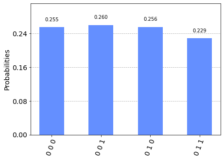

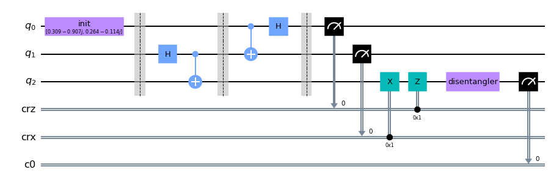

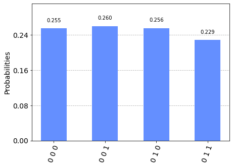

```python
inverse_init_gate = init_gate.gates_to_uncompute()

## SETUP
qr = QuantumRegister(3, name="q")   # Protocol uses 3 qubits
crz = ClassicalRegister(1, name="crz") # and 2 classical registers
crx = ClassicalRegister(1, name="crx")
qc = QuantumCircuit(qr, crz, crx)

## STEP 0
# First, let's initialize Alice's q0
qc.append(init_gate, [0])
qc.barrier()

## STEP 1
# Now begins the teleportation protocol
create_bell_pair(qc, 1, 2)
qc.barrier()

## STEP 2
# Send q1 to Alice and q2 to Bob
alice_gates(qc, 0, 1)

## STEP 3
# Alice then sends her classical bits to Bob
measure_and_send(qc, 0, 1)

## STEP 4
# Bob decodes qubits
bob_gates(qc, 2, crz, crx)

## STEP 5
# reverse the initialization process
qc.append(inverse_init_gate, [2])

# Need to add a new ClassicalRegister
# to see the result
cr_result = ClassicalRegister(1)
qc.add_register(cr_result)
qc.measure(2,2)

# Display the circuit
print(qc.draw(output="mpl"))

# Run the experiment
t_qc = transpile(qc, sim)
t_qc.save_statevector()
counts = sim.run(t_qc).result().get_counts()
plot_histogram(counts)
```

### Demonstration on real IBM-Q hardware

```
Figure(1049.8x264.88)
```

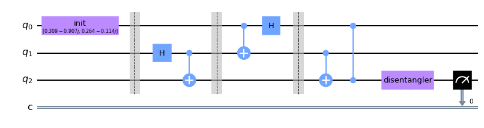

```python
from qiskit import IBMQ
from qiskit.providers.ibmq import least_busy
from qiskit.tools.monitor import job_monitor
#IBMQ.save_account('e9081f374d2f5bf456d39ef26990f8ca0067304ec50c21286fd1e03e2fb97efb65bf279fe02955f3b6ec2a3da22c1fc56ed6ff29181d6c4bf666c9c7f07840f8')

def new_bob_gates(qc, a, b, c):
    qc.cx(b, c)
    qc.cz(a, c)

qc = QuantumCircuit(3,1)

# First, let's initialize Alice's q0
qc.append(init_gate, [0])
qc.barrier()

# Now begins the teleportation protocol
create_bell_pair(qc, 1, 2)
qc.barrier()
# Send q1 to Alice and q2 to Bob
alice_gates(qc, 0, 1)
qc.barrier()
# Alice sends classical bits to Bob
new_bob_gates(qc, 0, 1, 2)

# We undo the initialization process
qc.append(inverse_init_gate, [2])

# See the results, we only care about the state of qubit 2
qc.measure(2,0)

# View the results:
print(qc.draw(output="mpl"))

run_on_ibm_hardware = False

if run_on_ibm_hardware:
    provider = IBMQ.load_account()
    # get the least-busy backend at IBM and run the quantum circuit there
    backend = least_busy(provider.backends(filters=lambda b: b.configuration().n_qubits >= 3 and
                                       not b.configuration().simulator and b.status().operational==True))
    t_qc = transpile(qc, backend, optimization_level=3)
    # Default is to run 1024 times
    job = backend.run(t_qc)
    job_monitor(job)  # displays job status under cell

    # Get the results and display them
    exp_result = job.result()
    exp_counts = exp_result.get_counts(qc)
    plot_histogram(exp_counts)
    print(exp_counts)
    print(provider)
    print(f"The experimental error rate : {exp_counts['1']/sum(exp_counts.values()):.3f}")
```

## Grover's Algorithm

Uses Grover's Algorithm to solve a 2x2 binary Sudoku puzzle:

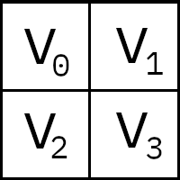

There are 4 conditions to check for a correct solution:

v0 ≠ v1 # check along top row  
v2 ≠ v3 # check along bottom row  
v0 ≠ v2 # check down left column  
v1 ≠ v3 # check down right column

First add code to list these comparisons and how to check for a valid row or column:

```python
clause_list = [[0,1],
               [0,2],
               [1,3],
               [2,3]]

def XOR(qc, a, b, output):
    qc.cx(a, output)
    qc.cx(b, output)
```

The final state of the bits c0, c1, c2, c3 will only all be 1 in the case that the assignments of v0, v1, v2, v3 are a solution to the sudoku. To complete our checking circuit, we want a single bit to be 1 if (and only if) all the clauses are satisfied; this way we can look at just one bit to see if our assignment is a solution. We can do this using a multi-controlled-Toffoli-gate in the oracle:

```python
def sudoku_oracle(qc, clause_list, clause_qubits):
    # Compute clauses
    i = 0
    for clause in clause_list:
        XOR(qc, clause[0], clause[1], clause_qubits[i])
        i += 1

    # Flip 'output' bit if all clauses are satisfied
    qc.mct(clause_qubits, output_qubit)

    # Uncompute clauses to reset clause-checking bits to 0
    i = 0
    for clause in clause_list:
        XOR(qc, clause[0], clause[1], clause_qubits[i])
        i += 1
```

Next, define and display (with 4 bits) the diffuser circuit:  
U$_{s}$ = H$^{⊗n}$U$_{f0}$H$^{⊗n}$ = 2 |s><s| - 1  
which represents a rotation around the |s> (superposition) axis.

Since U$_{f0}$ preserves |0>$^{⊗n}$ but reverses the phase of everything else, first rotate around the x-axis (X gate), which converts |000...0> to |111...1>. For the single case of |111...1>, the controlled Z gate, constructed by surrounding a controlled X with Hadamards (Z = HXH), results in a phase flip for this one case only. To understand this better, following is a 3-bit multi-controlled-Z gate (HZH) surrounded by Xs. Note from the unitary matrix that only the phase of |000...0> is reversed, as required by U$_{f0}$.

$$ \text{Circuit = } \begin{bmatrix} -1 & 0 & 0 & 0 & 0 & 0 & 0 & 0 \\ 0 & 1 & 0 & 0 & 0 & 0 & 0 & 0 \\ 0 & 0 & 1 & 0 & 0 & 0 & 0 & 0 \\ 0 & 0 & 0 & 1 & 0 & 0 & 0 & 0 \\ 0 & 0 & 0 & 0 & 1 & 0 & 0 & 0 \\ 0 & 0 & 0 & 0 & 0 & 1 & 0 & 0 \\ 0 & 0 & 0 & 0 & 0 & 0 & 1 & 0 \\ 0 & 0 & 0 & 0 & 0 & 0 & 0 & 1 \\ \end{bmatrix} $$

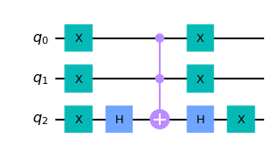

```python
def U𝑓0(qc, nqubits, display=False):
    # Apply transformation |00..0> -> |11..1> (X-gates)
    for qubit in range(nqubits):
        qc.x(qubit)
    # Do multi-controlled-Z gate
    qc.h(nqubits-1)
    # Multi-controlled Toffoli: If the first nqubits-1 bits are
    # all 1, a Pauli-X (NOT) is applied to the last bit.
    qc.mct(list(range(nqubits-1)), nqubits-1)
    qc.h(nqubits-1)
    # Apply transformation |11..1> -> |00..0>
    for qubit in range(nqubits):
        qc.x(qubit)
    if display:
        display_circuit(qc)
        display_unitary_matrix(qc)
U𝑓0(QuantumCircuit(3), 3, display=True)
```

```
<qiskit.circuit.gate.Gate at 0x7fdfd3447fd0>
```

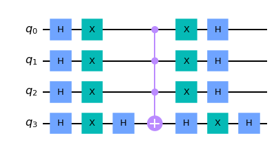

```python
def diffuser(nqubits, display=False):
    qc = QuantumCircuit(nqubits)
    # Apply transformation |s> -> |00..0> (H-gates)
    for qubit in range(nqubits):
        qc.h(qubit)
    # Apply Uf0
    Uf0(qc, nqubits, False)
    # Apply transformation |00..0> -> |s>
    for qubit in range(nqubits):
        qc.h(qubit)
    if display:
        display_circuit(qc)
    # We will return the diffuser as a gate
    U_s = qc.to_gate()
    U_s.name = "U$_s$"
    return U_s

diffuser(4, True)
```

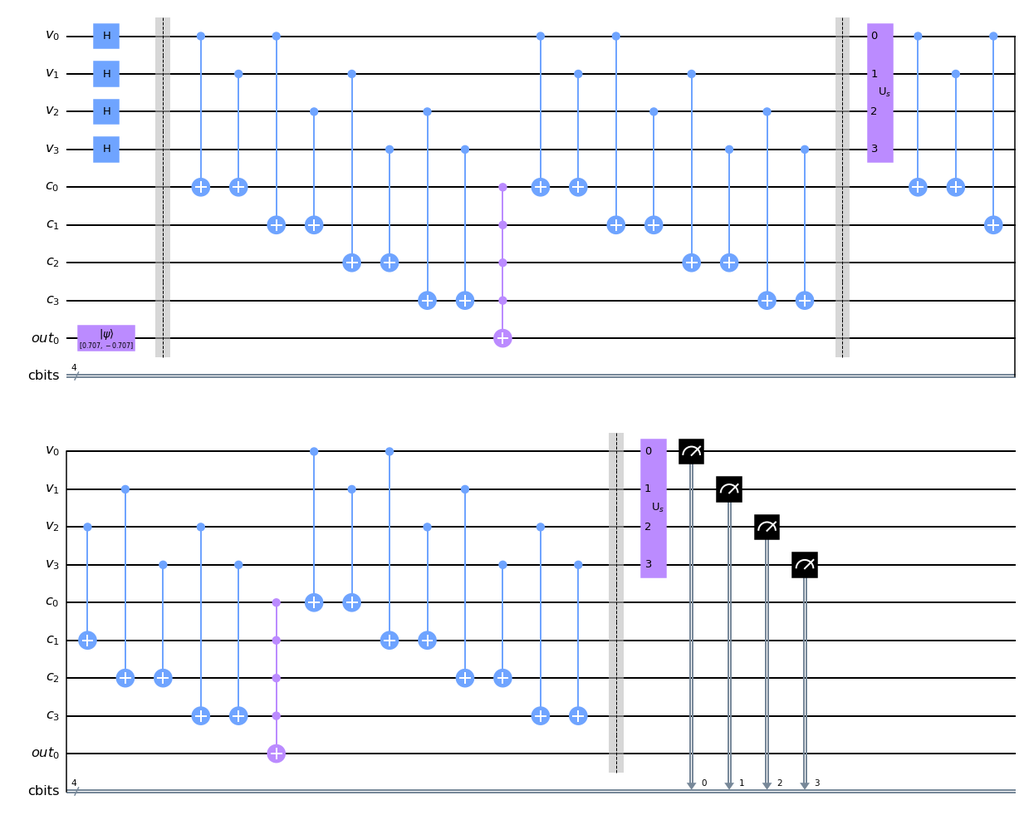

```python
var_qubits = QuantumRegister(4, name='v')
clause_qubits = QuantumRegister(4, name='c')
output_qubit = QuantumRegister(1, name='out')
cbits = ClassicalRegister(4, name='cbits')
qc = QuantumCircuit(var_qubits, clause_qubits, output_qubit, cbits)

# Initialize 'out0' in state |->
qc.initialize([1, -1]/np.sqrt(2), output_qubit)

# Initialize qubits in state |s>
qc.h(var_qubits)
qc.barrier()  # for visual separation

## First Iteration
# Apply our oracle
sudoku_oracle(qc, clause_list, clause_qubits)
qc.barrier()  # for visual separation
# Apply our diffuser
qc.append(diffuser(4), [0,1,2,3])

## Second Iteration
sudoku_oracle(qc, clause_list, clause_qubits)
qc.barrier()  # for visual separation
# Apply our diffuser
qc.append(diffuser(4), [0,1,2,3])

# Measure the variable qubits
qc.measure(var_qubits, cbits)

#qc.draw(fold=-1)
display_circuit(qc)
```

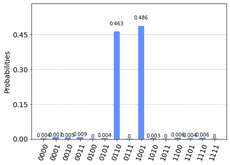

```python
# Simulate and plot results
aer_sim = Aer.get_backend('aer_simulator')
transpiled_qc = transpile(qc, aer_sim)
qobj = assemble(transpiled_qc)
result = aer_sim.run(qobj).result()
display_histogram(result)
```

## Quantum Fourier Transform

```python
def qft_rotations(circuit, n):
    """Performs QFT on the first n qubits in circuit (without swaps)"""
    if n == 0:
        return circuit
    n -= 1
    circuit.h(n)  # First apply the Hadamard gate
    for qubit in range(n):
        circuit.cp(pi/2**(n-qubit), qubit, n)  # Apply controlled phase gate
    # At the end of our function, we call the same function again on
    # the next qubits (we reduced n by one earlier in the function)
    qft_rotations(circuit, n)
```

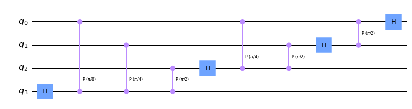

```python
# Using the slider, see how this circuit scales
from qiskit_textbook.widgets import scalable_circuit
scalable_circuit(qft_rotations)
```

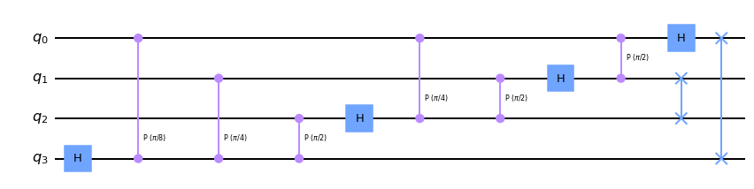

```python
# Finalize the circuit by performing the qubit swaps at the end
def swap_registers(circuit,n ):
    for qubit in range(n//2):
        circuit.swap(qubit, n-qubit-1)
    return circuit

def qft(circuit, n):
    """QFT on the first n qubits in circuit"""
    qft_rotations(circuit, n)
    swap_registers(circuit, n)
    return circuit

# Let's see how it looks:
qc = QuantumCircuit(4)
qft(qc, 4)
display_circuit(qc)
```

```python
def inverse_qft(circuit, n):
    """Does the inverse QFT on the first n qubits in circuit"""
    # First we create a QFT circuit of the correct size
    qft_circ = qft(QuantumCircuit(n), n)
    # Then we take the inverse of this circuit
    invqft_circ = qft_circ.inverse()
    # And add it to the first n qubits in our existing circuit
    circuit.append(invqft_circ, circuit.qubits[:n])
    return circuit.decompose()  # decompose allows us to see the individual gates
```

Put our qubits in the state $|\widetilde{5}\rangle$ and apply the inverse QFT:

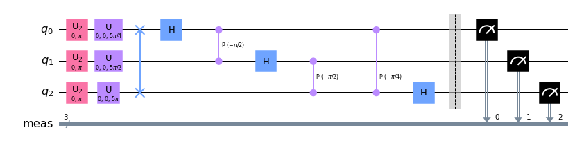

```python
# Puts qubits in the state QFT|5>
nqubits = 3
number = 5
qc = QuantumCircuit(nqubits)
for qubit in range(nqubits):
    qc.h(qubit)
qc.p(number*pi/4, 0)
qc.p(number*pi/2, 1)
qc.p(number*pi, 2)

# Apply the inverse QFT
qc = inverse_qft(qc, nqubits)
qc.measure_all()
display_circuit(qc)
```

```python
# Run on real hardware
run_on_ibm_hardware = False

if run_on_ibm_hardware:
    # Load our saved IBMQ accounts and get the least busy backend device with less than or equal to nqubits
    IBMQ.load_account()
    provider = IBMQ.get_provider(hub='ibm-q')
    backend = least_busy(provider.backends(filters=lambda x: x.configuration().n_qubits >= nqubits
                                           and not x.configuration().simulator
                                           and x.status().operational==True))
    print("least busy backend: ", backend)
```

```python
if run_on_ibm_hardware:
    shots = 2048
    transpiled_qc = transpile(qc, backend, optimization_level=3)
    job = backend.run(transpiled_qc, shots=shots)
    job_monitor(job)
```

```python
if run_on_ibm_hardware:
    counts = job.result().get_counts()
    plot_histogram(counts)
```

## Quantum Phase Estimation

We use 5 qubits: the first 4 are the n measurement (counting) qubits, and the last is $|\psi\rangle$. For the unitary operatory, let's use qiskit's cp(), a controlled phase gate, which in this example will apply the phase $\theta = {1 \over 3}$. Since the phase is applied to |1>, we start with $|\psi\rangle$ in that state.

```python
def qft_dagger1(qc, n):
    """n-qubit QFTdagger the first n qubits in circ"""
    # Don't forget the Swaps!
    for qubit in range(n//2):
        qc.swap(qubit, n-qubit-1)
    for j in range(n):
        for m in range(j):
            qc.cp(-math.pi/float(2**(j-m)), m, j)
        qc.h(j)
```

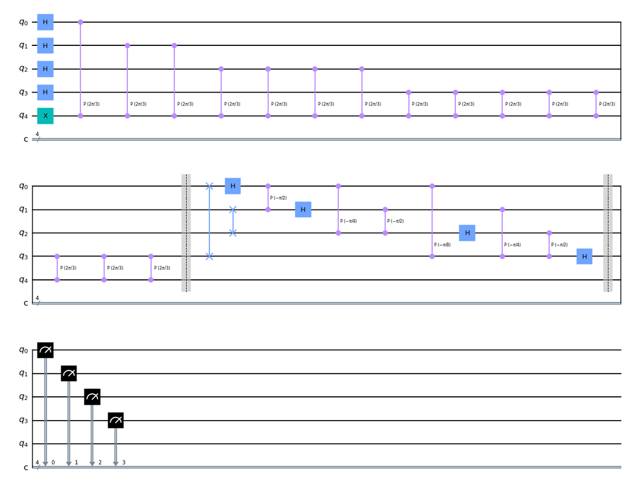

```python
import math

# Create and set up circuit
qpe3 = QuantumCircuit(5, 4)

# Apply H-Gates to counting qubits:
for qubit in range(4):
    qpe3.h(qubit)

# Prepare our eigenstate |psi>:
qpe3.x(4)

# Do the controlled-U operations:
angle = 2*math.pi/3
repetitions = 1
for counting_qubit in range(4):
    for i in range(repetitions):
        qpe3.cp(theta=angle, control_qubit=counting_qubit, target_qubit=4);
    repetitions *= 2

# Do the inverse QFT:
qpe3.barrier()
qft_dagger1(qpe3, n=4)

# # Measure of course!
qpe3.barrier()
for n in range(4):
    qpe3.measure(n,n)

display_circuit(qpe3)
```

Now display the results on a simulator. We're expecting the result $\theta = 0.3333\dots$, where the output histogram runs from 0 to 1.

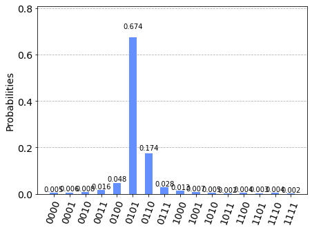

```python
# Let's see the results!
aer_sim = Aer.get_backend('aer_simulator')
shots = 4096
t_qpe3 = transpile(qpe3, aer_sim)
qobj = assemble(t_qpe3, shots=shots)
results = aer_sim.run(qobj).result()
display_histogram(results)
```

Now run the same algorithm on real hardware.

```python
run_on_ibm_hardware = False

if run_on_ibm_hardware:
    IBMQ.load_account()
    from qiskit.tools.monitor import job_monitor
    provider = IBMQ.get_provider(hub='ibm-q')
    backend = least_busy(provider.backends(filters=lambda x: x.configuration().n_qubits >= 5
                                       and not x.configuration().simulator
                                       and x.status().operational==True))
    print("least busy backend: ", backend)

    # Run with 2048 shots
    shots = 2048
    t_qpe3 = transpile(qpe3, backend, optimization_level=3)
    job = backend.run(t_qpe3, shots=shots)
    job_monitor(job)
```

```python
# get the results from the computation
if run_on_ibm_hardware:
    results = job.result()
    display_histogram(results)
```

## Shor's Algorithm and Prime Factorization

Let’s look at the periodic function:

$$ f(x) = a^x \bmod{N}$$

where $a$ and $N$ are positive integers, $a$ is less than $N$, and they have no common factors. The period, or order ($r$), is the smallest (non-zero) integer such that:

$$a^r \bmod N = 1 $$

Shor’s solution was to use QFE on the unitary operator:

$$ U|y\rangle \equiv |ay \bmod N \rangle $$

To see how this is helpful, let’s work out what an eigenstate of U might look like. If we started in the state $|1\rangle$, we can see that each successive application of U will multiply the state of our register by $a \pmod N$, and after $r$ applications we will arrive at the state $|1\rangle$ again. For example with $a = 3$ and $N = 35$:

$$\begin{aligned} U|1\rangle &= |3\rangle & \\ U^2|1\rangle &= |9\rangle \\ U^3|1\rangle &= |27\rangle \\ & \vdots \\ U^{(r-1)}|1\rangle &= |12\rangle \\ U^r|1\rangle &= |1\rangle \end{aligned}$$

Let’s look at the case in which the phase of the $k$th state is proportional to $k$:

$$\begin{aligned} |u_1\rangle &= \tfrac{1}{\sqrt{r}}\sum_{k=0}^{r-1}{e^{-\tfrac{2\pi i k}{r}}|a^k \bmod N\rangle}\\[10pt] U|u_1\rangle &= e^{\tfrac{2\pi i}{r}}|u_1\rangle \end{aligned} $$

This is a particularly interesting eigenvalue as it contains $r$. In fact, $r$ has to be included to make sure the phase differences between the $r$ computational basis states are equal. This is not the only eigenstate with this behaviour; to generalise this further, we can multiply an integer, $s$, to this phase difference, which will show up in our eigenvalue:

$$\begin{aligned} |u_s\rangle &= \tfrac{1}{\sqrt{r}}\sum_{k=0}^{r-1}{e^{-\tfrac{2\pi i s k}{r}}|a^k \bmod N\rangle}\\[10pt] U|u_s\rangle &= e^{\tfrac{2\pi i s}{r}}|u_s\rangle \end{aligned} $$

We now have a unique eigenstate for each integer value of $s$ where $$0 \leq s \leq r-1.$$ Very conveniently, if we sum up all these eigenstates, the different phases cancel out all computational basis states except $|1\rangle$:

$$ \tfrac{1}{\sqrt{r}}\sum_{s=0}^{r-1} |u_s\rangle = |1\rangle$$

Since the computational basis state $|1\rangle$ is a superposition of these eigenstates, which means if we do QPE on $U$ using the state $|1\rangle$, we will measure a phase:

$$\phi = \frac{s}{r}$$

Where $s$ is a random integer between $0$ and $r-1$.

### Example: Factoring 15

To see an example of factoring on a small number of qubits, we will factor 15, which we all know is the product of the not-so-large prime numbers 3 and 5. So let's set N to 15 and find a non-trivial coprime $a$.

```python
from math import gcd
from numpy.random import randint
N = 15  # The number we're trying to factor into primes
n_count = 8  # number of counting qubits
#np.random.seed(1) # This is to make sure we get reproduceable results
while True:
    a = randint(2, N)
    while a not in [2,7,8,11,13]:
        print("a = {0}".format(a))
        a = randint(2, N)
        continue
    g = gcd(a, N)
    if g != 1:
        print("Trying again for a = {0} since greatest common divisor is {1}, which is greater than 1".format(a, g))
    else:
        break
print("Success! N = {0}, a = {1}".format(N, a))
```

```
a = 4
a = 5
a = 4
Success! N = 15, a = 2
```

The following creates the circuits for $U$ where:

$U|y\rangle = |ay \bmod N \rangle = |ay\bmod 15\rangle $

To create $U^x$, we will simply repeat the circuit $x$ times. The function `c_amod15` returns the controlled-U gate for `a`, repeated `power` times.

```python
def c_amod15(a, power):
    """Controlled multiplication by a mod 15"""
    if a not in [2,7,8,11,13]:
        raise ValueError("'a' must be 2,7,8,11 or 13")
    U = QuantumCircuit(4)
    for iteration in range(power):
        if a in [2,13]:
            U.swap(0,1)
            U.swap(1,2)
            U.swap(2,3)
        if a in [7,8]:
            U.swap(2,3)
            U.swap(1,2)
            U.swap(0,1)
        if a == 11:
            U.swap(1,3)
            U.swap(0,2)
            # For odd a, need to invert the output
        if a in [7,11,13]:
            for q in range(4):
                U.x(q)
    U = U.to_gate()
    U.name = "%i^%i mod 15" % (a, power)
    c_U = U.control()
    return c_U
```

Next is another version of the inverse QFT:

```python
def qft_dagger(n):
    """n-qubit QFTdagger the first n qubits in circ"""
    qc = QuantumCircuit(n)
    # Don't forget the Swaps!
    for qubit in range(n//2):
        qc.swap(qubit, n-qubit-1)
    for j in range(n):
        for m in range(j):
            qc.cp(-np.pi/float(2**(j-m)), m, j)
        qc.h(j)
    qc.name = "QFT†"
    return qc
```

With these building blocks we can easily construct the circuit for Shor's algorithm, which is simple the QFE circuit applied to $|\phi\rangle = |1\rangle_4$:

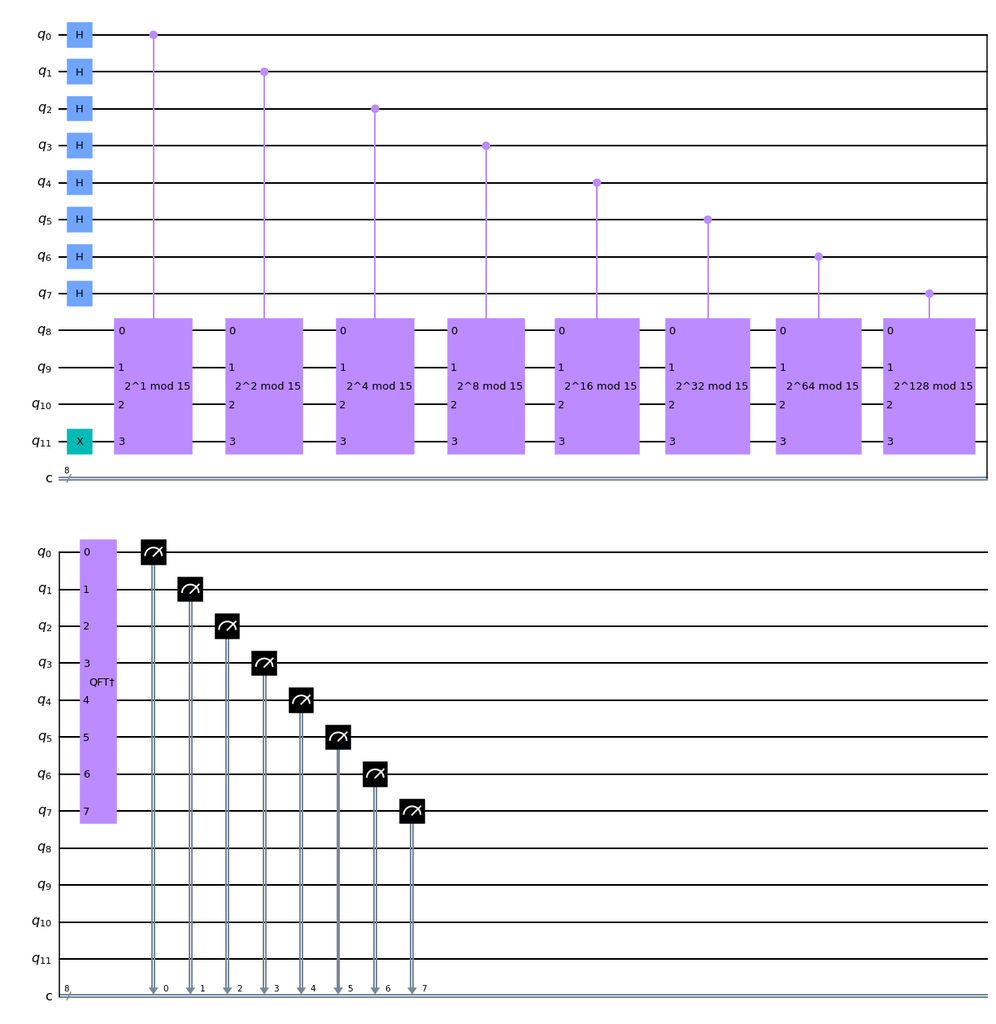

```python
# Create QuantumCircuit with n_count counting qubits
# plus 4 qubits for U to act on
qc = QuantumCircuit(n_count + 4, n_count)

# Initialize counting qubits
# in state |+>
for q in range(n_count):
    qc.h(q)

# And auxiliary register in state |1>
qc.x(3+n_count)

# Do controlled-U operations
for q in range(n_count):
    qc.append(c_amod15(a, 2**q),
             [q] + [i+n_count for i in range(4)])

# Do inverse-QFT
qc.append(qft_dagger(n_count), range(n_count))

# Measure circuit
qc.measure(range(n_count), range(n_count))
display_circuit(qc)
```

Let's see what results we measure:

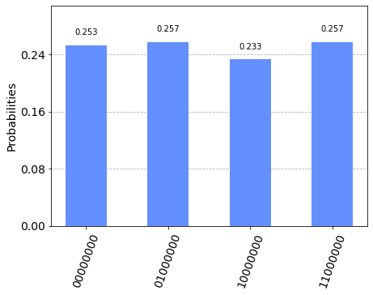

```python
aer_sim = Aer.get_backend('aer_simulator')
t_qc = transpile(qc, aer_sim)
qobj = assemble(t_qc)
results = aer_sim.run(qobj).result()
display_histogram(results)
```

Now let's put it all together:

```python
def qpe_amod15(a):
    qc = QuantumCircuit(4+n_count, n_count)
    for q in range(n_count):
        qc.h(q)     # Initialize counting qubits in state |+>
    qc.x(3+n_count) # And auxiliary register in state |1>
    for q in range(n_count): # Do controlled-U operations
        qc.append(c_amod15(a, 2**q),
                 [q] + [i+n_count for i in range(4)])
    qc.append(qft_dagger(n_count), range(n_count)) # Do inverse-QFT
    qc.measure(range(n_count), range(n_count))
    # Simulate Results
    aer_sim = Aer.get_backend('aer_simulator')
    # Setting memory=True below allows us to see a list of each sequential reading
    t_qc = transpile(qc, aer_sim)
    qobj = assemble(t_qc, shots=1)
    result = aer_sim.run(qobj, memory=True).result()
    readings = result.get_memory()
    print("Register Reading: " + readings[0])
    phase = int(readings[0],2)/(2**n_count)
    print("Corresponding Phase: %f" % phase)
    return phase

factors_found = 0
attempt = 0
from fractions import Fraction
while factors_found < 2:
    attempt += 1
    factors_found = 0
    print("\nAttempt %i (a = %i):" % (attempt, a))
    phase = qpe_amod15(a) # Phase = s/r
    frac = Fraction(phase).limit_denominator(N) # Denominator should (hopefully!) tell us r
    r = frac.denominator
    print("Result: r = %i" % r)
    if phase != 0:
        # Guesses for factors are gcd(x^{r/2} ±1 , 15)
        guesses = [gcd(a**(r//2)-1, N), gcd(a**(r//2)+1, N)]
        print("Guessed Factors: %i and %i" % (guesses[0], guesses[1]))
        for guess in guesses:
            if guess not in [1,N] and (N % guess) == 0: # Check to see if guess is a factor
                print("*** Non-trivial factor found: %i ***" % guess)
                factors_found += 1
```

```
Attempt 1 (a = 2):
Register Reading: 11000000
Corresponding Phase: 0.750000
Result: r = 4
Guessed Factors: 3 and 5
*** Non-trivial factor found: 3 ***
*** Non-trivial factor found: 5 ***
```

## Version Information

```python
import qiskit.tools.jupyter
%qiskit_version_table
```

Version Information

| Qiskit Software | Version |
| --- | --- |
| Qiskit | 0.27.0 |
| Terra | 0.17.4 |
| Aer | 0.8.2 |
| Ignis | 0.6.0 |
| Aqua | 0.9.2 |
| IBM Q Provider | 0.14.0 |
| System information |  |
| Python | 3.9.5 (default, Jun 4 2021, 12:28:51) [GCC 7.5.0] |
| OS | Linux |
| CPUs | 4 |
| Memory (Gb) | 15.50619125366211 |
| Fri Oct 29 11:37:26 2021 EDT |  |